# Laboratorium 3

Martyna Konopacka

### Zadanie 1

Przedział ufności dla wartości oczekiwanej na poziomie $1-\alpha$ jest postaci
$$(\bar{X} - z_{1 - \frac{\alpha}{2}}\frac{\sigma}{\sqrt{n}} , \bar{X} + z_{1 - \frac{\alpha}{2}}\frac{\sigma}{\sqrt{n}})$$
gdzie $z_{1 - \alpha/2}$ jest kwantylem rzędu $1 - {\alpha/2}$ rozkładu standardowego (dla poziomu ufności 95% mamy $z_{\alpha/2} = 1.96$), $\bar{X}$ to średnia z próby. W zadaniu zakładamy, że odchylenie standardowe jest znane i wynosi $\sigma = 1$.

Celem eksperymentu jest sprawdzenie, w jakim odsetku powtórzeń eksperymentu średnia populacji $\mu = 0$ rzeczywiście mieści się w wyznaczonym przedziale.

Wyniki dla podpunktow b i c

| mu | sd | n | poziom | iter | trafienia | sr_szer_przedzialu |
| --- | --- | --- | --- | --- | --- | --- |
| 0 | 1 | 100 | 0.95 | 1000 | 0.938 | 0.3919928 |
| 0 | 1 | 200 | 0.95 | 1000 | 0.953 | 0.2771808 |

W obu przypadkach odsetki są bardzo zbliżone do wyznaczonych teoretycznie wartości - jest tak dlatego, że $n$ powyżej $30$ jest już wystarczająco duże. Dzięki sprawdzeniu średnich szerokości przedziałów można zauważyć, jak zwiększenie liczebności próby wpływa na zawężenie przedziału.

### Zadanie 2

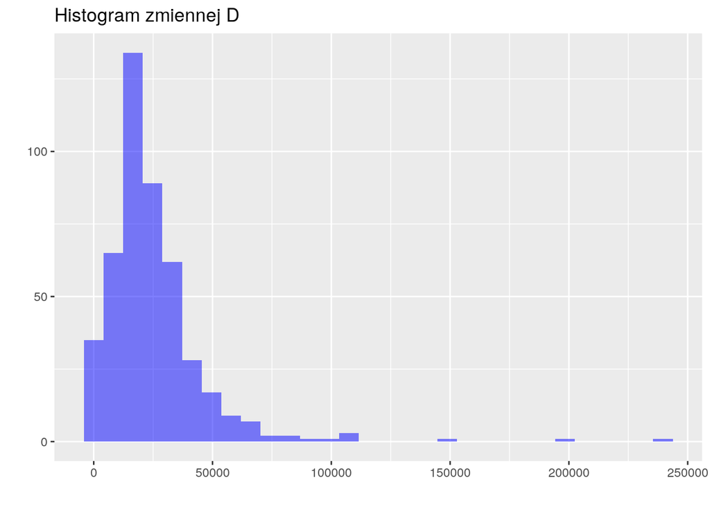

Patrząc na histogram można domyślać się, że rozkład nie będzie normalny - w szczególności normalność psują obserwacje odstające z prawej strony wykresu. W części pierwszej sprawdzimy, czy odsetki obserwacji zmiennej $D$ w odległościach $\sigma, 2\sigma, 3\sigma$ od średniej są zbliżone do wartości wynikających z reguły trzech sigm. Odchylenie standardowe w populacji z zadania wynosi $22087.09$, a średnia $24977.43$.

```
## [1] 0.6800000 0.8689956
```

```
## [1] 0.9500000 0.9694323
```

```
## [1] 0.9970000 0.9847162
```

Największą różnicę widać dla pierwszego przedziału - leży w nim znacznie większy odsetek obserwacji, niż wynikałoby z zasady trzech sigm. Jest tak dlatego, że przez udział obserwacji odstających przedział ten jest szerszy, niż powinien.

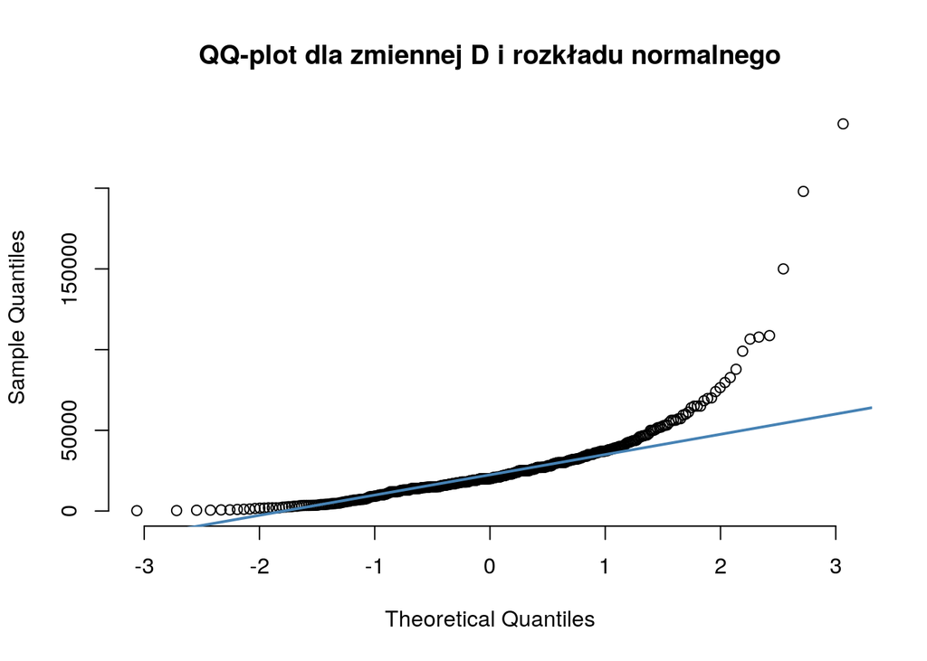

Na wykresie można zauważyć obserwacje odstające zaburzające normalność rozkładu. Bliżej środka punkty leżą blisko prostej.

### Zadanie 3a

**Lemat**

Niech $D = U^2$, $E[U] = \mu$ oraz $Var[U] = \sigma^2$. Wtedy $E[D] = \mu^2 + \sigma^2$. Dowód:
$$E[D] = E[U^2] = E[U - \mu + \mu]^2 = E[U-\mu]^2 - 2E[(U-\mu)\mu] + E[\mu]^2 = Var[U] - 2\mu E[U - \mu] + \mu^2 = \sigma^2 + \mu^2$$

Stąd $E[D] - (E[U])^2 = \sigma^2 + \mu^2 - \mu^2 = \sigma^2 \geq 0$.

W celu obliczenia pierwiastka, najpierw przesuwamy cały wektor D o jego najniższą wartość - w ten sposób unikniemy problemu z wartościami ujemnymi. średnia $D_1$ powinna być większa niż kwadrat średniej $U$ o wartość wariancji $U$. Uwaga: wbudowana funkcja `var` oblicza nieobciążony estymator wariancji z $n-1$ w mianowniku - w tym przypadku chodzi nam jednak o wariancję liczoną “dla populacji”, czyli `mean((U-mean(U))^2` i tylko taki sposób daje dobre wyniki.

Ponieważ dane zostały przesunięte, w podpunkcie a. porównałam kwadrat średniej $U = \sqrt{D_1}$ ze średnią zmiennej $D_1$. Różnica pomiędzy średnimi $D1$ i $D$ jest równa początkowemu przesunięciu.

```
##   sq_mean_U  mean_D1  sigma_U diff_mD1_mU2
## 1  21874.92 25207.43 3332.503     3332.503
```

[figure not shown]

Ostatnią częścią podpunktu jest wyznaczenie frakcji osób z wykształceniem wyższym - zadanie realizuje poniższy kod:

```r
pw <- nrow(filter(income, Education >= 5))/nrow(income)
pw
```

```
## [1] 0.268559
```

### Zadanie 3b

Estymatorem $\mu$ jest średnia próbkowa, a estymatorem $p$ proporcja w próbie. Konstrukcja przedziału ufności dla $\mu$ została opisana w poprzednich zadaniach. Klasyczny przedział ufności dla $p$ w próbie o wystarczająco dużej liczebności (pozwalającej na przybliżanie rozkładem normalnym, powiedzmy $n > 30$) jest postaci:
$$(\bar{p} - u_{1 - \frac{\alpha}{2}} \sqrt{\frac{\bar{p}(1-\bar{p})}{n}}), \bar{p} + u_{1 - \frac{\alpha}{2}} \sqrt{\frac{\bar{p}(1-\bar{p})}{n}})$$
gdzie $\bar{p}$ jest estymatorem $p$.

```r
przedzial_mu <- function(V, sd_pop, poziom = 0.95){
  # Funkcja zwraca lewy i prawy brzeg przedziału ufności dla wartosci oczekiwanej; znany parametr sd_pop -> rozklad normalny
  s <- sd_pop
  meanX <- mean(V)
  n <- length(V)
  u <- qnorm(p = 1 - (1-poziom)/2)
  low <- meanX - u*s/sqrt(n)
  high <- meanX + u*s/sqrt(n)
  return(c(low = low, high = high))
}

przedzial_p <- function(V, poziom = 0.95){
  # Funkcja zwraca lewy i prawy brzeg przedziału ufności dla p; V powinien być wektorem TRUE / FALSE
  p <- sum(V)/length(V) # estymator p
  n <- length(V)
  u <- qnorm(p = 1 - (1-poziom)/2)
  low <- p - u*sqrt((p*(1-p)/n))
  high <- p + u*sqrt((p*(1-p)/n))
  return(c(low = low, high = high))
}
```

Sprawdzimy, czy przedziały konstruowane o próbę o liczebności 200 zawierają rzeczywiste wartości parametrów:

```
##        low real_mu_U     high inside
## 1 142.9789  147.9017 158.9799   TRUE
```

[output not shown]

```
##         low   real_p      high inside
## 1 0.2038355 0.268559 0.3261645   TRUE
```

Wszystkie przedziały zawierały prawdziwe wartości parametru. Szanse na to w każdym z przypadków wynosiły 95%.

### Zadanie 3c

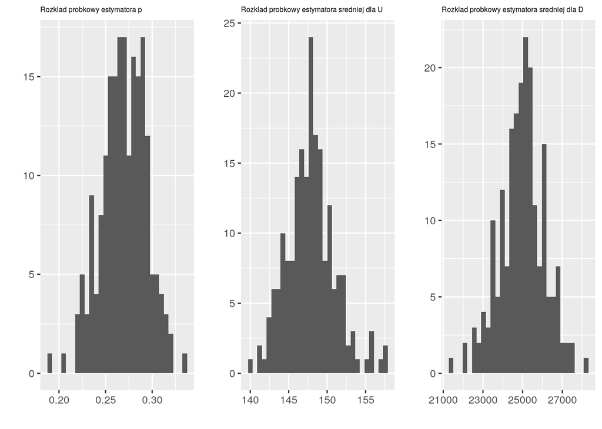

```r
it = 200
est_p <- numeric(length = it)
est_mu_U <- numeric(length = it)
est_mu_D <- numeric(length = it)

# liczniki: ile razy prawdziwy parametr zawiera sie w przedziale?
zawiera_p <- 0
zawiera_U <- 0
zawiera_D <- 0

for (i in 1:it){
  # pobranie prób
  sampleV <- sample(Vp,200)
  sampleU <- sample(U,200)
  sampleD <- sample(D,200)
  # obliczenie estymatorow
  p <- sum(sampleV)/200
  mu_U <- mean(sampleU)
  mu_D <- mean(sampleD)
  # zapisanie ich do wektorow w celu pozniejszego rysowania histogramu
  est_p[i] <- p
  est_mu_U[i] <- mu_U
  est_mu_D[i] <- mu_D
  # sprawdzenie przedzialow
  pp <- przedzial_p(sampleV)
  pU <-przedzial_mu(sampleU, sd_U)
  pD <- przedzial_mu(sampleD, sd_D)
  if (between(pw, pp["low"], pp["high"])){zawiera_p <- zawiera_p + 1}
  if (between(mean(U), pU["low"], pU["high"])){zawiera_U <- zawiera_U + 1}
  if (between(mean(D), pD["low"], pD["high"])){zawiera_D <- zawiera_D + 1}
}

p1 <- qplot(est_p, geom = 'histogram', main = 'Rozklad probkowy estymatora p', xlab = '') + theme(plot.title = element_text(size= 6))
p2 <- qplot(est_mu_U, geom = 'histogram', main = 'Rozklad probkowy estymatora sredniej dla U', xlab = '') + theme(plot.title = element_text(size= 6))
p3 <- qplot(est_mu_D, geom = 'histogram', main = 'Rozklad probkowy estymatora sredniej dla D', xlab = '') + theme(plot.title = element_text(size=6))
grid.arrange(p1,p2,p3, ncol = 3)
```

Rozkłady przypominają rozkład normalny. W dalszej części zadania sprawdzamy jeszcze, jak często przedziały ufności zawierały prawdziwy parametr:

```r
data.frame(frakcja = zawiera_p / 200, srednia_U = zawiera_U / 200, srednia_D = zawiera_D / 200)
```

```
##   frakcja srednia_U srednia_D
## 1   0.985     0.985      0.99
```

Odsetki są znacząco wyższe niż teoretyczne - myślę, że przedział jest błędnie skonstruowany i zbyt szeroki.

### Zadanie 4

W tym zadaniu, ponieważ nieznane są parametry populacji, korzystamy z kwantyli rozkładu t-Studenta.

```r
library(stats)
load('grades.RData')
IQ <- grades$IQ
P <- grades$TestPsych
przedzial_mu_t <- function(V, poziom = 0.95){
  # Funkcja zwraca lewy i prawy brzeg przedziału ufności dla wartosci oczekiwanej z nieznanym parametrem w populacji - korzystając z rozkładu t-Studenta
  s <- sd(V) ## z dokumentacji wynika, że to liczy estymator z mianownikiem n-1
  meanX <- mean(V)
  n <- length(V)
  t <- qt(p = 1 - (1-poziom)/2, df = n-1) # kwantyl rozkładu studenta z n-1 df
  low <- meanX - t*s/sqrt(n)
  high <- meanX + t*s/sqrt(n)
  return(c(low = low, high = high))
}
przedzial_mu_t(IQ)
```

```
##      low     high
## 105.9535 111.8927
```

```r
przedzial_mu_t(P)
```

```
##      low     high
## 54.16301 59.76006
```